# Лабораторная работа 1. Корреляция и линейная регрессия.

## Цель работы

Исследовать зависимость количества скачиваний программного продукта от количества посещений сайта средствами Scikit-Learn.

## Исходные данные

- *количество просмотров сайта за 10 дней*
- *количество скачиваний продукта*

```python
import pandas as pd
import numpy as np
import matplotlib.pyplot as plt
import seaborn as sns
from sklearn.linear_model import LinearRegression
```

### Данные о посещениях и скачиваний на сайте

```python
data = pd.read_csv('siteData.csv')
print(data)
```

```
   days  views  download
0     5   5252        21
1     6   7620        46
2     7    941         9
3     8   1159         8
4     9    485         3
5    10    299         6
6    11    238         4
7    12    195         2
8    13    181         2
9    14    180         2
```

[figure not shown]

### Загрузка данных

```python
days = np.array(data['days'])
views = np.array(data['views'])
download = np.array(data['download'])
```

### Зависимость количества регистраций от посещений

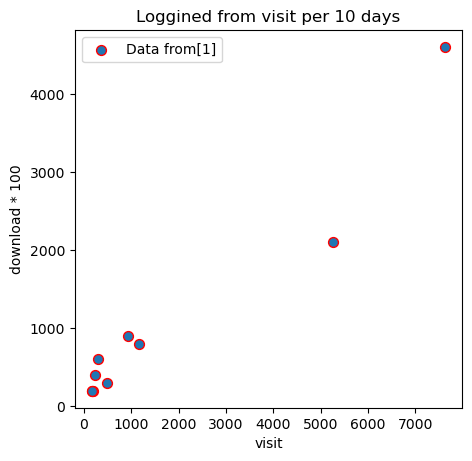

```python
plt.figure(figsize=(5,5), dpi=100)
plt.scatter(views, download*100, edgecolor="red", s=50,cmap='coolwarm',label="Data from[1]")
plt.ylabel("download * 100")
plt.xlabel("visit")
plt.title("Loggined from visit per 10 days")
plt.legend()
plt.show()
```

## Метод решения

Для построения линейной модели предлагается использовать метод наименьших квадратов [1].

### Суть метода наименьших квадратов

Задача заключается в нахождении коэффициентов линейной зависимости, при которых функция двух переменных $a$ и $b$ формула $F(a,b)=\sum_{i=1}^{n}(y_i-(ax_i+b))^2$ принимает наименьшее значение. То есть, при данных $a$ и $b$ сумма квадратов отклонений экспериментальных данных от найденной прямой будет наименьшей. В этом вся суть метода наименьших квадратов.

Таким образом, решение примера сводится к нахождению экстремума функции двух переменных.

### Вывод формул

$$ \begin{equation} \left\{ \begin{array}{ll} \frac{d F(a,b)}{da} = 0 \\ \frac{d F(a,b)}{db} = 0 \end{array}\right. \end{equation} $$$$ \begin{equation} \left\{ \begin{array}{ll} -2 \sum_{i=1}^{n}(y_i - (ax_i + b))x_i = 0 \\ -2 \sum_{i=1}^{n}(y_i - (ax_i + b)) = 0 \end{array}\right. \end{equation} $$$$ \begin{equation} \left\{ \begin{array}{ll} a \sum_{i=1}^{n}{x_i}^2 + b \sum_{i=1}^{n}x_i = \sum_{i=1}^{n}x_i y_i \\ a \sum_{i=1}^{n}x_i + \sum_{i=1}^{n}b = \sum_{i=1}^{n}y_i \end{array}\right. \end{equation} $$$$ \begin{equation} \left\{ \begin{array}{ll} a \sum_{i=1}^{n}{x_i}^2 + b \sum_{i=1}^{n}x_i = \sum_{i=1}^{n}x_i y_i \\ a \sum_{i=1}^{n}x_i + nb = \sum_{i=1}^{n}y_i \end{array}\right. \end{equation} $$$$ \begin{equation} \left\{ \begin{array}{ll} a = \frac{n\sum_{i=1}^{n}x_iy_i - \sum_{i=1}^{n}x_i \sum_{i=1}^{n}y_i}{n\sum_{i=1}^{n}{x_i}^2 - (\sum_{i=1}^{n}x_i)^2}\\ b = \frac{\sum_{i=1}^{n}y_i - a \sum_{i=1}^{n}x_i}{n} \end{array}\right. \end{equation} $$

## Реализация

### С помощью самописных функций

среднее значение:

```
def m(x):
    return np.sum(x)/N
```

Дисперсия:

```
def D(x):
    return np.sum((x-m(x))**2)/N
```

Коэффициент корреляции:

```
def k(x,z):
    return (np.sum((x-m(x))*(z-m(z))))/(N*np.sqrt(D(x)*D(z)))
```

Коэффициент А:

```
A=(m(views)*m(download)-np.sum(views*download)/N)/(m(views)**2-np.sum(views**2)/N)
```

Коэффициент В:

```
B=m(download)-A*m(views)
```

### С помощью библиотеки *NumPy*

```python
def directFunc(x):
    return x

def squareFunc(x):
    return x*x

def coef(x, y):
    a = calculateA(x, y)
    b = calculateB(x, y, a)
    return (a,b)

def avg(x, func):
    sum = summ(x,func)
    return sum/len(x)

def summ(x, func):
    sum =0;
    for i in range(0, len(x)):
        sum+=func(x[i])
    return sum

def arrMultSum(x,y):
    if(len(x) != len(y)):
        raise RuntimeError('Failed to open database') from exc

    sum=0
    for i in range(len(x)):
        sum += x[i]*y[i]
    return sum

def calculateA(x, y):
    numerator = avg(x, directFunc)*avg(y, directFunc) - (arrMultSum(x,y) * 1/len(x))
    denumerator = avg(x, directFunc)**2 - avg(x, squareFunc)
    return numerator/denumerator

def calculateB(x,y,A):
    mx = avg(x, directFunc)
    my = avg(y, directFunc)
    return my - A * mx
```

Используя исходные формулы, находим коэффициенты линии регрессии:

```python
coefNp = coef(views, download)
print("Коэффициент a =", coefNp[0])
print("Коэффициент b =", coefNp[1])
```

```
Коэффициент a = 0.005140175787546552
Коэффициент b = 1.7930090716104576
```

Сверим полученные результаты с коэффициентами, полученными с использованием встроенных функций библиотеки *Scikit Learn*.

### С помощью библиотеки *Scikit Learn* [3]

```python
visit_lin = views[:, np.newaxis]
download_lin = download[:, np.newaxis]

linear_regressor = LinearRegression()  # create object for the class
linear_regressor.fit(visit_lin, download_lin)  # perform linear regression

coefSl = [linear_regressor.coef_[0][0], linear_regressor.intercept_[0]]

print("Коэффициент a =", coefSl[0])
print("Коэффициент b =", coefSl[1])
```

```
Коэффициент a = 0.005140175787546551
Коэффициент b = 1.7930090716104594
```

```python
if round(coefNp[0], 10) == round(coefSl[0], 10) and round(coefNp[1], 10) == round(coefSl[1], 10):
    print("Результаты совпадают")
```

```
Результаты совпадают
```

## Построение графиков

С помощью полученных коэффициентов был построен график линейной регрессии.

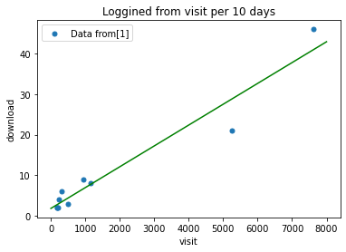

```python
def getLinerPoints(x_data, coefs):
    arrY =[]
    for i in range(len(x_data)):
        arrY += [coefs[0] * x_data[i] + coefs[1]]
    return (x_data, arrY)

def drawLinearRegAndData(data, line_data):
    plt.scatter(data[0], data[1], s=25, cmap='cool',label="Data from[1]")
    plt.plot(line_data[0], line_data[1], color="green")
    plt.ylabel("download")
    plt.xlabel("visit")
    plt.title("Loggined from visit per 10 days")
    plt.legend()
    plt.show()

line_data = getLinerPoints([0, 8000], coefSl)
drawLinearRegAndData((views, download), line_data)
```

## Ответы на вопросы

**Вопрос 1**: при количестве посещений сайта в **8000** человек, сколько планируется получить зарегистрировавшихся программный продукт?  
**Ответ**:

```python
views = [[8000]]
registered = linear_regressor.predict(views)
print(int(registered[0][0]))
```

```
42
```

**Вопрос 2**: для обеспечения 500 скачиваний продукта, сколько человек должны зайти на сайт?  
**Ответ**:

```python
linear_regressor.fit(download_lin, visit_lin)
visit_fit = linear_regressor.predict([[500]])
print(int(visit_fit[0][0]))
```

```
91190
```

# Список литературы

1. Конверсия посетителей сайта: https://habr.com/ru/company/nerepetitor/blog/250633/
2. Библиотека seaborn: Statistical Data Visualization: https://seaborn.pydata.org/
3. Библиотека scikit-learn: Регрессия: https://scikit-learn.org/stable/index.html